# Skicast Pro… now with widgets!

2011-01-23

In a continuing effort to differentiate Skicast from the other ski condition apps out there in Android-land, I’ve released a new version of Skicast Pro that features some spiffy new homescreen widgets. These widgets allow you to view the current conditions at your favorite resorts at-a-glance without opening Skicast. Tapping the widget opens the main app’s favorites screen.

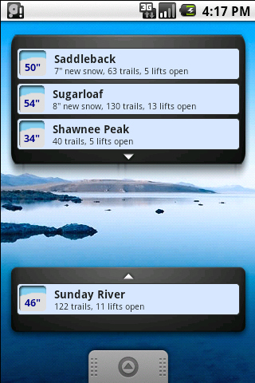

Skicast’s sales have been, quite frankly, a bit disappointing. The data feed for the app is kinda pricey, and it doesn’t look like I’m going to recoup that expense. I had assumed that there was a larger potential user base for Skicast than my other app, Tidecast. That may still be the case, but right now Tidecast downloads are outpacing Skicast Pro downloads almost 5-to-1.

So, to try to boost its flagging sales, I’ve added the widgets. I’ve also introduced House Ads in the Free edition that try to upsell the Pro edition. My AdMob ads only get about a 40% fill rate, so house ads seemed like an obvious place to try to plug the upgrade - this is especially true for getting the message out about the new features in the Pro version.

We’ll see how it goes! I intend to slow down the pace of Android development for a while to tackle a few other mobile platforms. I’ve started ports of both Skicast and Tidecast to iOS before, but I got distracted by other things and abandoned them. I think I might revive those projects for a bit … I’m anxious to see how they perform in the App Store vs. the Android Market.

[This work is licensed under a [Creative Commons Attribution-NonCommercial-NoDerivatives 4.0 International License](http://creativecommons.org/licenses/by-nc-nd/4.0/) .](http://creativecommons.org/licenses/by-nc-nd/4.0/)